# Lab 10 - Trees, Bagging, RF, Boosting XGBoost

# Learning goals

- Perform classification and regression with tree-based methods in R
- Recognize that tree-based methods are capable of capturing non-linearities by splitting multiple times on the same variables
- Compare the performance of classification trees, bagging, random forests, and boosting for predicting heart disease based on the `heart` data.

# Lab description

For this lab we will be working with the `heart` dataset that you can download from [here](https://github.com/JSC370/JSC370-2024/blob/main/data/heart.csv)

### Setup packages

You should install and load `rpart` (trees), `randomForest` (random forest), `gbm` (gradient boosting) and `xgboost` (extreme gradient boosting).

```r
install.packages(c("rpart", "rpart.plot", "randomForest", "gbm", "xgboost"))
```

### Load packages and data

```r
library(tidyverse)
library(rpart)
library(rpart.plot)
library(randomForest)
library(gbm)
library(xgboost)
library(caret)

heart <- read_csv("https://raw.githubusercontent.com/JSC370/JSC370-2024/main/data/heart.csv") |>
  mutate(
    AHD = 1 * (AHD == "Yes"),
    ChestPain = factor(ChestPain),
    Thal = factor(Thal)
  )

head(heart)
```

```
## # A tibble: 6 × 14
##     Age   Sex ChestPain    RestBP  Chol   Fbs RestECG MaxHR ExAng Oldpeak Slope
##   <dbl> <dbl> <fct>         <dbl> <dbl> <dbl>   <dbl> <dbl> <dbl>   <dbl> <dbl>
## 1    63     1 typical         145   233     1       2   150     0     2.3     3
## 2    67     1 asymptomatic    160   286     0       2   108     1     1.5     2
## 3    67     1 asymptomatic    120   229     0       2   129     1     2.6     2
## 4    37     1 nonanginal      130   250     0       0   187     0     3.5     3
## 5    41     0 nontypical      130   204     0       2   172     0     1.4     1
## 6    56     1 nontypical      120   236     0       0   178     0     0.8     1
## # ℹ 3 more variables: Ca <dbl>, Thal <fct>, AHD <dbl>
```

## Question 1: Trees

- Split the `heart` data into training and testing (70-30%)

```r
set.seed(370)
train <- sample(1:nrow(heart), round(0.7 * nrow(heart)))
heart_train <- heart[train, ]
heart_test <- heart[-train, ]
```

- Fit a classification tree using rpart, plot the full tree. We are trying to predict AHD. Set minsplit = 10, minbucket = 3, and do 10 cross validations.

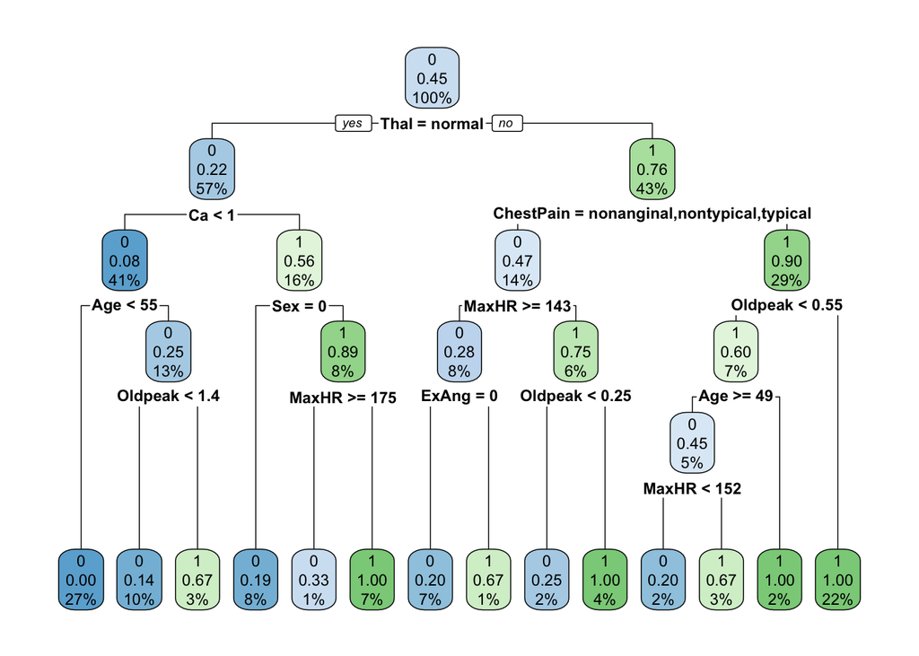

```r
heart_tree <- rpart(
  AHD ~ .,
  heart_train,
  method = "class",
  minsplit = 10,
  minbucket = 3,
  cp = 0,
  xval = 10
)
rpart.plot(heart_tree)
```

- Plot the complexity parameter table for an rpart fit and find the optimal cp

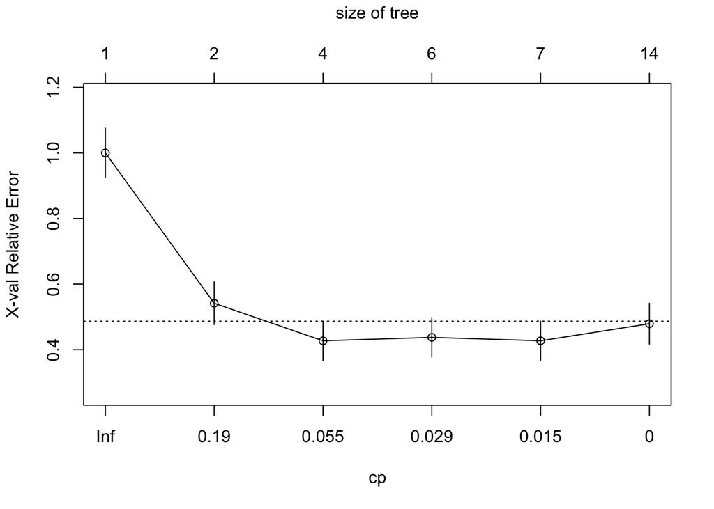

```r
plotcp(heart_tree)
```

```r
printcp(heart_tree)
```

```
##
## Classification tree:
## rpart(formula = AHD ~ ., data = heart_train, method = "class",
##     minsplit = 10, minbucket = 3, cp = 0, xval = 10)
##
## Variables actually used in tree construction:
## [1] Age       Ca        ChestPain ExAng     MaxHR     Oldpeak   Sex
## [8] Thal
##
## Root node error: 96/212 = 0.45283
##
## n= 212
##
##         CP nsplit rel error  xerror     xstd
## 1 0.500000      0   1.00000 1.00000 0.075496
## 2 0.072917      1   0.50000 0.54167 0.065256
## 3 0.041667      3   0.35417 0.42708 0.059903
## 4 0.020833      5   0.27083 0.43750 0.060452
## 5 0.010417      6   0.25000 0.42708 0.059903
## 6 0.000000     13   0.17708 0.47917 0.062516
```

```r
optimalcp <- heart_tree$cptable |>
  as.data.frame() |>
  slice_min(order_by = xerror, n = 1) |>
  head(1) |>
  select(CP) |>
  pull()
optimalcp
```

```
## [1] 0.04166667
```

- Prune the tree

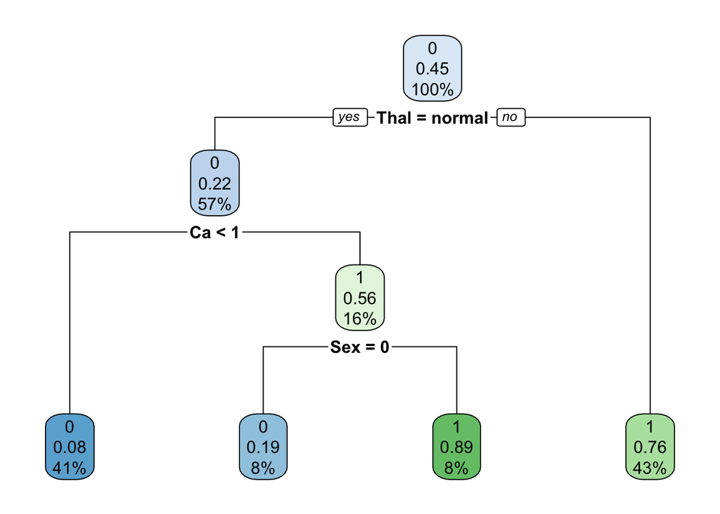

```r
heart_tree_prune <- prune(heart_tree, cp = optimalcp)
rpart.plot(heart_tree_prune)
```

- Compute the test misclassification error

```r
heart_pred <- predict(heart_tree_prune, heart_test) |>
  as.data.frame() |>
  mutate(AHD = ifelse(`1` > 0.5, 1, 0))

conf_mat <- table(true = heart_test$AHD, predicted = heart_pred$AHD)
conf_mat |> as.data.frame()
```

```
##   true predicted Freq
## 1    0         0   29
## 2    1         0    9
## 3    0         1   19
## 4    1         1   34
```

```r
num_correct <- conf_mat |>
  as.data.frame() |>
  filter(true == predicted) |>
  summarize(sum = sum(Freq)) |>
  select(sum) |>
  pull()

acc <- (num_correct) / nrow(heart_pred)
acc
```

```
## [1] 0.6923077
```

- Fit the tree with the optimal complexity parameter to the full data (training + testing)

```r
heart_tree <- rpart(
  AHD ~ .,
  data = heart,
  method = "class",
  cp = optimalcp
)
```

- Find the Out of Bag (OOB) error for tree

```r
printcp(heart_tree)
```

```
##
## Classification tree:
## rpart(formula = AHD ~ ., data = heart, method = "class", cp = optimalcp)
##
## Variables actually used in tree construction:
## [1] Ca        ChestPain Thal
##
## Root node error: 139/303 = 0.45875
##
## n= 303
##
##         CP nsplit rel error  xerror     xstd
## 1 0.474820      0   1.00000 1.00000 0.062401
## 2 0.046763      1   0.52518 0.61871 0.056460
## 3 0.041667      5   0.33813 0.50360 0.052783
```

```r
min(heart_tree$cptable[, "xerror"]) * nrow(heart)
```

```
## [1] 152.5899
```

## Question 2: Bagging, Random Forest

- Compare the performance of classification trees (above), bagging, random forests for predicting heart disease based on the `heart` data.
- Use the training and testing sets from above. Train each of the models on the training data and extract the cross-validation (or out-of-bag error for bagging and Random forest).
- For bagging use `randomForest` with `mtry` equal to the number of features (all other parameters at their default values). Generate the variable importance plot using `varImpPlot` and extract variable importance from the `randomForest` fitted object using the `importance` function.

```r
heart_bag <- randomForest(
  as.factor(AHD) ~ .,
  heart_train,
  mtry = ncol(heart_train) - 1,
  na.action = na.omit
)
# oob error rate
sum(heart_bag$err.rate[, 1])
```

```
## [1] 107.5712
```

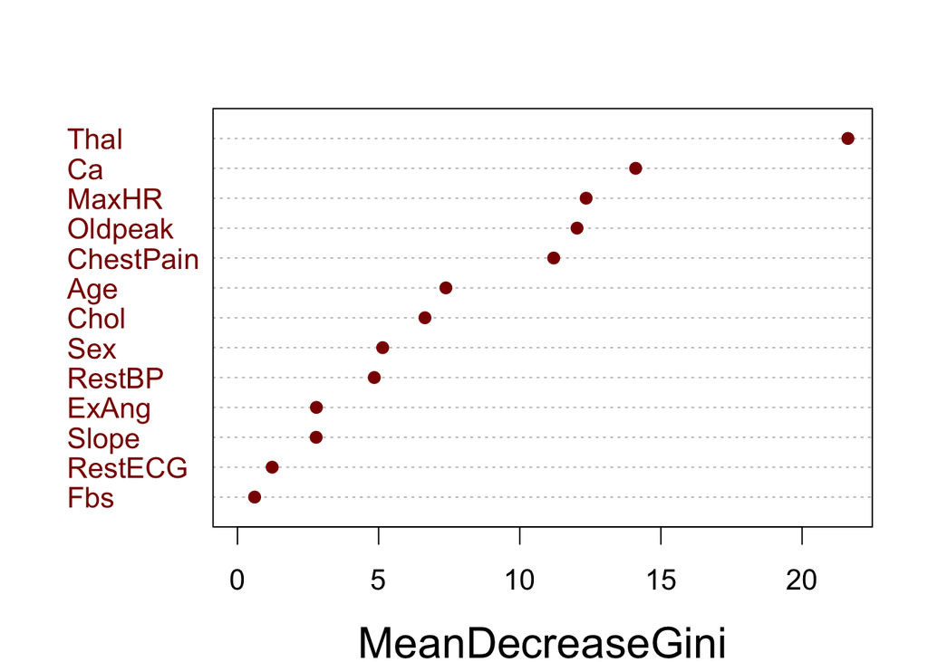

```r
varImpPlot(heart_bag,
  cex.lab = 1.5,
  cex.axis = 2,
  cex = 1.3,
  n.var = 13,
  main = "",
  pch = 16,
  col = "red4"
)
```

```r
importance(heart_bag)
```

```
##           MeanDecreaseGini
## Age               7.383041
## Sex               5.143497
## ChestPain        11.202275
## RestBP            4.846061
## Chol              6.640841
## Fbs               0.608045
## RestECG           1.230508
## MaxHR            12.350654
## ExAng             2.796019
## Oldpeak          12.028330
## Slope             2.786847
## Ca               14.104845
## Thal             21.623654
```

- For random forests use `randomForest` with the default parameters. Generate the variable importance plot using `varImpPlot` and extract variable importance from the `randomForest` fitted object using the `importance` function.

```r
heart_rf <- randomForest(
  as.factor(AHD) ~ .,
  data = heart_train,
  na.action = na.omit
)
# oob error rate
sum(heart_rf$err.rate[, 1])
```

```
## [1] 95.85259
```

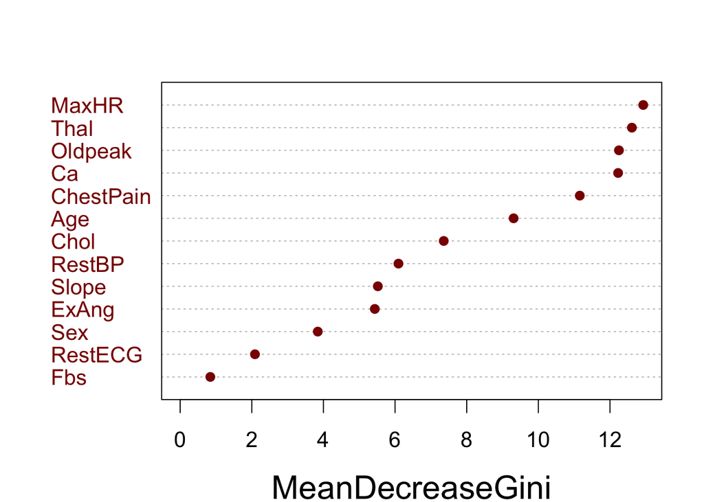

```r
varImpPlot(heart_rf,
  cex.lab = 1.5,
  cex.axis = 2,
  cex = 1.3,
  n.var = 13,
  main = "",
  pch = 16,
  col = "red4"
)
```

```r
importance(heart_rf)
```

```
##           MeanDecreaseGini
## Age              9.3097035
## Sex              3.8420799
## ChestPain       11.1570819
## RestBP           6.0946544
## Chol             7.3593854
## Fbs              0.8423667
## RestECG          2.0885510
## MaxHR           12.9285573
## ExAng            5.4343056
## Oldpeak         12.2504030
## Slope            5.5193315
## Ca              12.2268778
## Thal            12.6119699
```

# Question 3: Boosting

- For boosting use `gbm` with `cv.folds=5` to perform 5-fold cross-validation, and set `class.stratify.cv` to `TRUE` (heart disease outcome) so that cross-validation is performed stratifying by `AHD`. Plot the cross-validation error as a function of the boosting iteration/trees (the `$cv.error` component of the object returned by `gbm`) and determine whether additional boosting iterations are warranted. If so, run additional iterations with `gbm.more` (use the R help to check its syntax). Choose the optimal number of iterations. Use the `summary.gbm` function to generate the variable importance plot and extract variable importance/influence (`summary.gbm` does both). Generate 1D and 2D marginal plots with `gbm.plot` to assess the effect of the top three variables and their 2-way interactions.

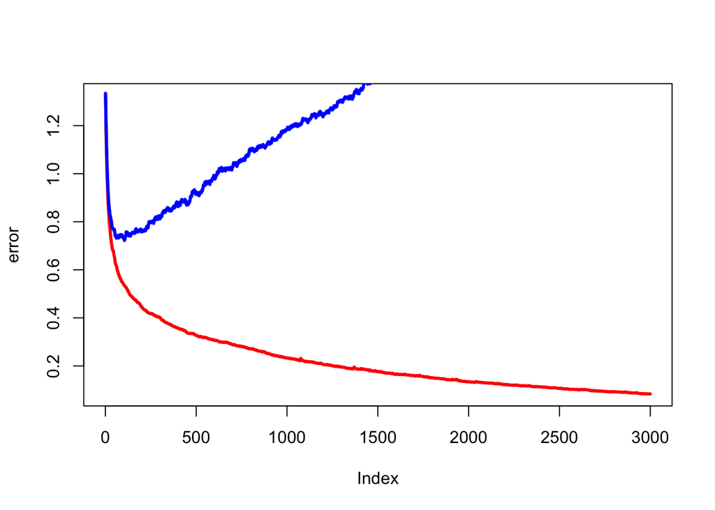

```r
heart_boost <- gbm(
  AHD ~ .,
  heart_train,
  distribution = "bernoulli",
  cv.folds = 5,
  class.stratify.cv = TRUE,
  n.trees = 3000
)
plot(heart_boost$train.error, ylab = "error", type = "l", col = "red", lwd = 3)
lines(heart_boost$cv.error, col = "blue", lwd = 3)
```

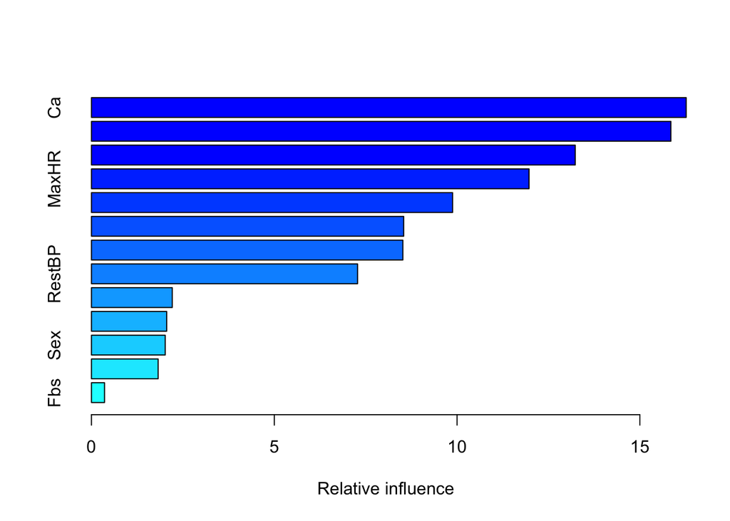

```
##                 var    rel.inf
## Ca               Ca 16.2672834
## Chol           Chol 15.8486343
## Age             Age 13.2321613
## MaxHR         MaxHR 11.9686885
## ChestPain ChestPain  9.8786278
## Oldpeak     Oldpeak  8.5403107
## Thal           Thal  8.5174489
## RestBP       RestBP  7.2793111
## RestECG     RestECG  2.2106910
## Slope         Slope  2.0571686
## Sex             Sex  2.0177501
## ExAng         ExAng  1.8241828
## Fbs             Fbs  0.3577414
```

```r
summary.gbm(heart_boost)
```

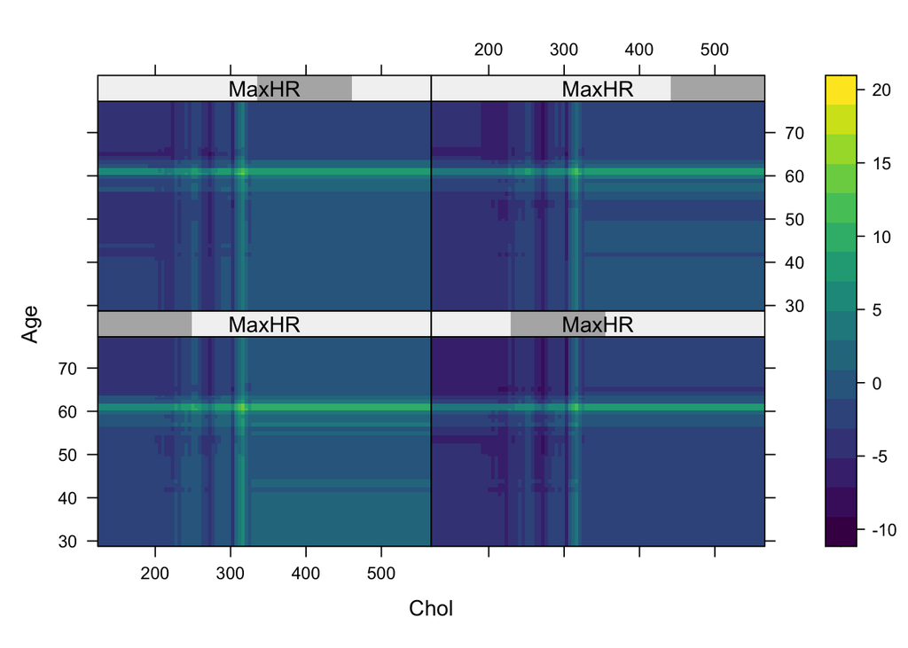

```r
plot(heart_boost, i.var = c(5, 1, 8))
```

## Question 4: Gradient Boosting

Evaluate the effect of critical boosting parameters (number of boosting iterations, shrinkage/learning rate, and tree depth/interaction). In `gbm` the number of iterations is controlled by `n.trees` (default is 100), the shrinkage/learning rate is controlled by `shrinkage` (default is 0.001), and interaction depth by `interaction.depth` (default is 1).

Note, boosting can overfit if the number of trees is too large. The shrinkage parameter controls the rate at which the boosting learns. Very small $\lambda$ can require using a very large number of trees to achieve good performance. Finally, interaction depth controls the interaction order of the boosted model. A value of 1 implies an additive model, a value of 2 implies a model with up to 2-way interactions, etc. the default is 1.

- Set the seed and train a boosting classification with `gbm` using 10-fold cross-validation (`cv.folds=10`) on the training data with `n.trees = 5000`, `shrinkage = 0.001`, and `interaction.depth =1`. Plot the cross-validation errors as a function of the boosting iteration and calculate the test MSE.

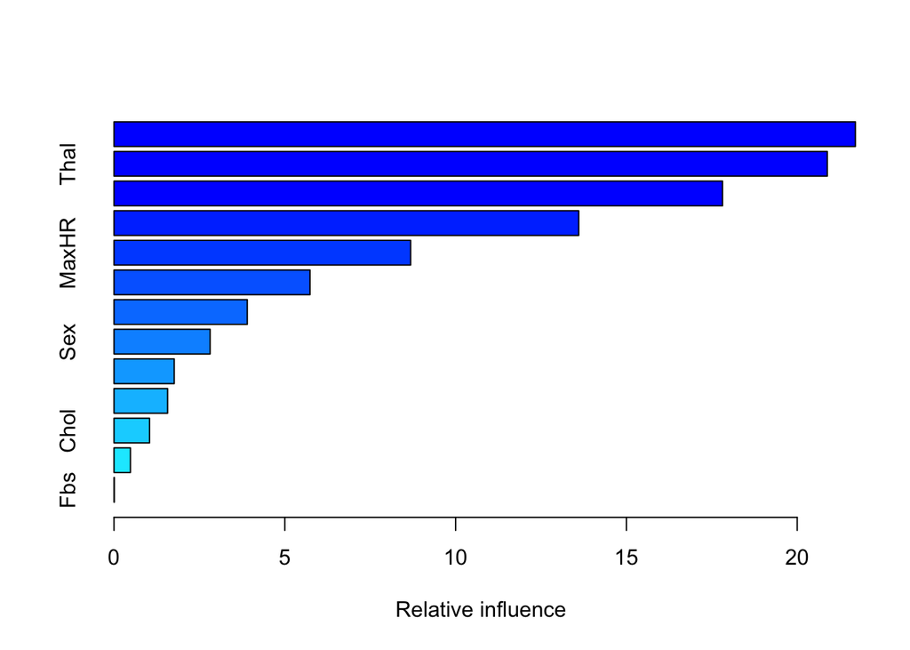

```
##                 var      rel.inf
## Ca               Ca 21.703362969
## Thal           Thal 20.880247146
## ChestPain ChestPain 17.814306271
## Oldpeak     Oldpeak 13.603998244
## MaxHR         MaxHR  8.683882739
## ExAng         ExAng  5.737419647
## Slope         Slope  3.901620499
## Sex             Sex  2.813812282
## Age             Age  1.763162008
## RestECG     RestECG  1.568703806
## Chol           Chol  1.040245385
## RestBP       RestBP  0.480255622
## Fbs             Fbs  0.008983381
```

```r
set.seed(301)
heart_boost <- gbm(
  AHD ~ .,
  data = heart[train, ],
  distribution = "bernoulli",
  n.trees = 5000,
  interaction.depth = 1,
  shrinkage = 0.001,
  cv.folds = 10,
  class.stratify.cv = TRUE
)

summary(heart_boost)
```

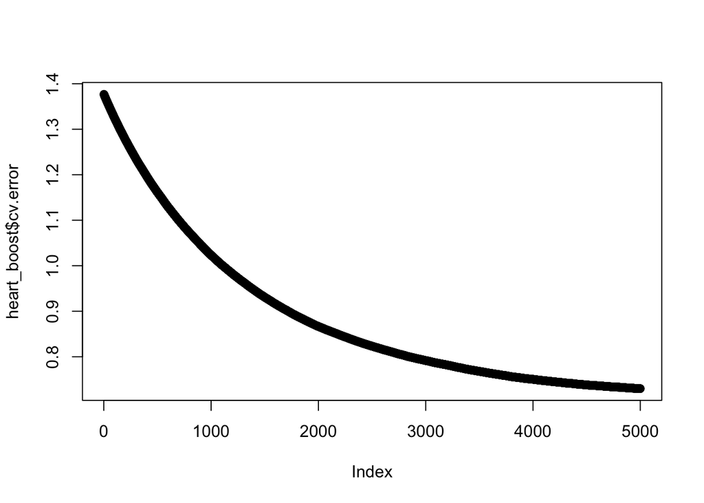

```r
plot(heart_boost$cv.error)
```

```r
yhat_boost <- predict(heart_boost, heart_test) # predict on test
```

```
## Using 4998 trees...
```

```r
# calculate MSE
mean((yhat_boost - heart_test$AHD) ^ 2)
```

```
## [1] 2.329897
```

- Repeat the above using the same seed and `n.trees=5000` with the following 3 additional combination of parameters: a) `shrinkage = 0.001`, `interaction.depth = 2`; b) `shrinkage = 0.01`, `interaction.depth = 1`; c) `shrinkage = 0.01`, `interaction.depth = 2`.

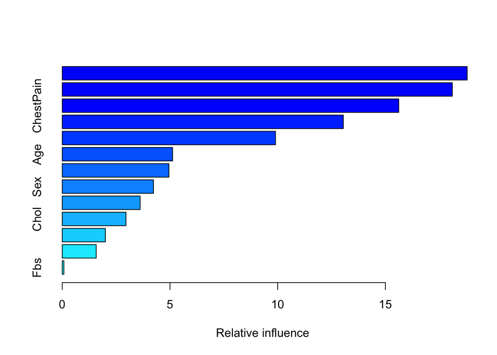

```
##                 var     rel.inf
## Ca               Ca 18.79673332
## Thal           Thal 18.10881412
## ChestPain ChestPain 15.62056195
## Oldpeak     Oldpeak 13.04720422
## MaxHR         MaxHR  9.89953346
## Age             Age  5.12067872
## ExAng         ExAng  4.95225728
## Sex             Sex  4.23309588
## Slope         Slope  3.61473737
## Chol           Chol  2.95658559
## RestECG     RestECG  2.00050701
## RestBP       RestBP  1.57480466
## Fbs             Fbs  0.07448642
```

```r
set.seed(301)
heart_boost1 <- gbm(
  AHD ~ .,
  data = heart[train, ],
  distribution = "bernoulli",
  n.trees = 5000,
  interaction.depth = 2,
  shrinkage = 0.001,
  cv.folds = 10,
  class.stratify.cv = TRUE
)

summary(heart_boost1)
```

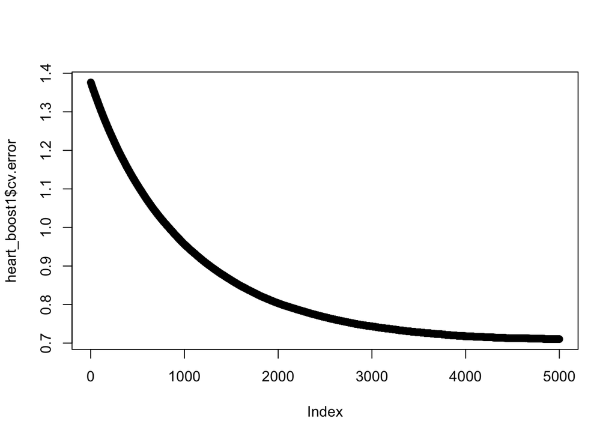

```r
plot(heart_boost1$cv.error)
```

```r
yhat_boost1 <- predict(heart_boost1, heart_test) # predict on test
```

```
## Using 4947 trees...
```

```r
# calculate MSE
mean((yhat_boost1 - heart_test$AHD) ^ 2)
```

```
## [1] 3.106806
```

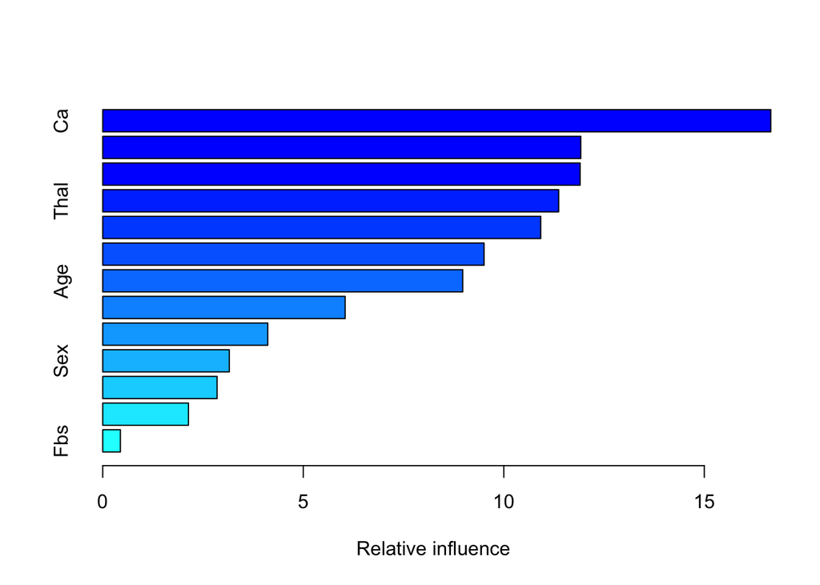

```
##                 var    rel.inf
## Ca               Ca 16.6579116
## ChestPain ChestPain 11.9199295
## MaxHR         MaxHR 11.9032646
## Thal           Thal 11.3688592
## Oldpeak     Oldpeak 10.9215902
## Chol           Chol  9.5085480
## Age             Age  8.9767172
## RestBP       RestBP  6.0447438
## ExAng         ExAng  4.1146220
## Sex             Sex  3.1555466
## Slope         Slope  2.8508243
## RestECG     RestECG  2.1370930
## Fbs             Fbs  0.4403499
```

```r
set.seed(301)
heart_boost2 <- gbm(
  AHD ~ .,
  data = heart[train, ],
  distribution = "bernoulli",
  n.trees = 5000,
  interaction.depth = 1,
  shrinkage = 0.01,
  cv.folds = 10,
  class.stratify.cv = TRUE
)

summary(heart_boost2)
```

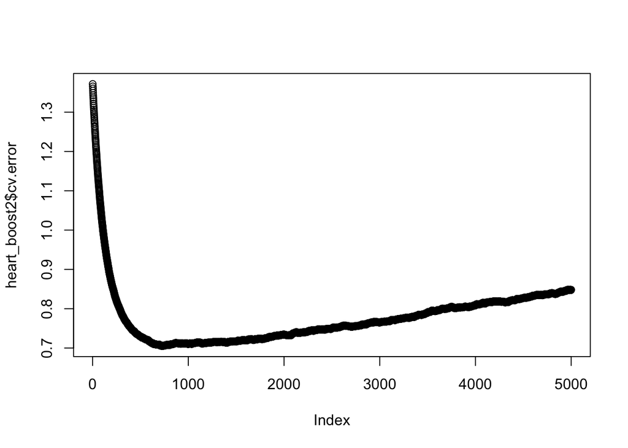

```r
plot(heart_boost2$cv.error)
```

```r
yhat_boost2 <- predict(heart_boost2, heart_test) # predict on test
```

```
## Using 726 trees...
```

```r
# calculate MSE
mean((yhat_boost2 - heart_test$AHD) ^ 2)
```

```
## [1] 3.239277
```

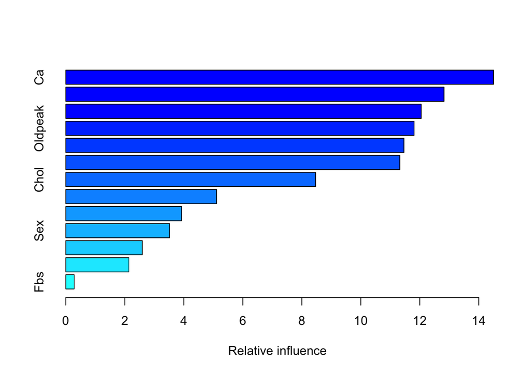

```
##                 var    rel.inf
## Ca               Ca 14.4979442
## MaxHR         MaxHR 12.8199139
## Thal           Thal 12.0490204
## Oldpeak     Oldpeak 11.8047192
## Age             Age 11.4618636
## ChestPain ChestPain 11.3217574
## Chol           Chol  8.4691469
## RestBP       RestBP  5.1104517
## ExAng         ExAng  3.9264495
## Sex             Sex  3.5215208
## Slope         Slope  2.5935643
## RestECG     RestECG  2.1391241
## Fbs             Fbs  0.2845241
```

```r
set.seed(301)
heart_boost3 <- gbm(
  AHD ~ .,
  data = heart[train, ],
  distribution = "bernoulli",
  n.trees = 5000,
  interaction.depth = 2,
  shrinkage = 0.01,
  cv.folds = 10,
  class.stratify.cv = TRUE
)

summary(heart_boost3)
```

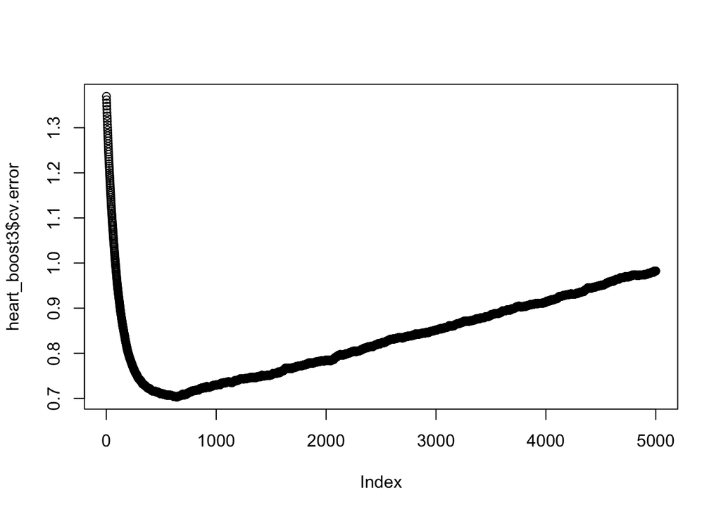

```r
plot(heart_boost3$cv.error)
```

```r
yhat_boost3 <- predict(heart_boost3, heart_test) # predict on test
```

```
## Using 644 trees...
```

```r
# calculate MSE
mean((yhat_boost3 - heart_test$AHD) ^ 2)
```

```
## [1] 3.869645
```

## Question 5: Extreme Gradient Boosting

Training an xgboost model with `xgboost` and perform a grid search for tuning the number of trees and the maximum depth of the tree. Also perform 10-fold cross-validation and determine the variable importance. Finally, compute the test MSE.

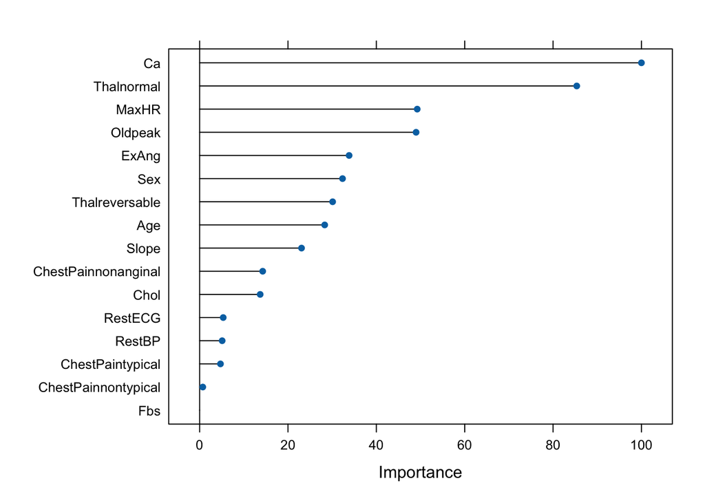

```r
train_control <- trainControl(method = "cv", number = 10, search = "grid")

tune_grid <- expand.grid(
  max_depth = c(1, 3, 5, 7), # larger makes model more complex and potentially overfit
  nrounds = (1:10) * 50, # number of trees
  # default values below
  eta = c(0.01, 0.1, 0.3), # learning rate (equivalent to shrinkage)
  gamma = 0, # Minimum loss reduction required to make a further partition on a leaf node of the tree. The larger gamma is, the more conservative the algorithm will be.
  subsample = 1,
  min_child_weight = 1,
  colsample_bytree = 0.6 # specify the fraction of columns to be subsampled
)

output <- capture.output(heart_xgb <- caret::train(
  as.factor(AHD) ~ .,
  heart_train,
  na.action = na.omit,
  method = "xgbTree",
  trControl = train_control,
  tuneGrid = tune_grid
))

varimp <- varImp(
  heart_xgb
)
plot(varimp)
```

```r
# Predict
xgb_pred <- predict(heart_xgb, heart_test)

# Compute MSE
mean((as.numeric(xgb_pred) - as.numeric(heart_test$AHD)) ^ 2)
```

```
## [1] 1.296703
```

# Deliverables

1. Questions 1-5 answered, pdf or html output uploaded to quercus